# Analysis of Spotify data

## Introduction

The succesfulness of the song is determined by various audio features which makes it to go up the ladder in the Top Billboard charts. The goal of the analysis is to determine the audio features of the song and their contibution to the Successfulness of the song. The various audio features include the danceability level, energy, tempo, valence, acousticness, liveliness, loudness etc. which contributes a major factor to make a song successful.

Here we see the analysis of the data that was gathered using Billboard’s Charts from Jan 1, 2000 - Dec. 31, 2005. The data set includes 350 songs that peaked within the Top 10 during that time. It also has 241 songs that peaked between 30-40 on the charts during that time.

```r
library(httr)
library(jsonlite)
library(curl)
```

```r
library(ggplot2)
library(reshape2)
library(stringr)
#install.packages("fuzzyjoin",repos='http://cran.us.r-project.org')
#install.packages("stringdist",repos='http://cran.us.r-project.org')
library(stringdist)
library(fuzzyjoin)
library(rpart)
library(tidyr)
```

## Spotify API configuration

The Spotify API configuration is the first and foremost step to form an interface with Spotify and R for analysis purpose. The key configurations are the Client key and client secret key given while creating the application in Spotify developer console.

The Request and Response urls are configured to get the playlist IDs and track IDS of the song that we have imported in our playlist. The authentication key called Oauth token is used to authenticate our user profile and request before it gives its response.

```r
response = POST('https://accounts.spotify.com/api/token',
              accept_json(),
              authenticate(spotifyKey, spotifySecret),
              body = list(grant_type = 'client_credentials'),
              encode = 'form',
              verbose()
)
```

```r
spotifyID <- "22vj7pwybpow4rrgw6acnxolq"
spotifyPlaylist <- "7ckg79YQQcX6yiCGNbrRBx"
artists_name <- data.frame()
name_track <- data.frame()
for(offset in c(0,100,200,300,400,500)){
        playlistTracksURL <- paste("https://api.spotify.com/v1/users/",
                                   spotifyID,
                                   "/playlists/",
                                   spotifyPlaylist,
                                   "/tracks?offset=",offset,
                                   sep="")



        HeaderValue = paste0('Bearer ', mytoken)
        getTracks <- GET(url=playlistTracksURL, add_headers(Authorization = HeaderValue))
        info <- jsonlite::fromJSON(toJSON(content(getTracks)))
        track <- unlist(info$items$track$id)
        name <- unlist(info$items$track$name)
        name_track1 <- as.data.frame(cbind(as.character(name),as.character(track)))
        name_track <- as.data.frame(rbind(name_track,name_track1))

        artists <- as.character()
        if(offset == 500){
                for(i in 1:82){

                        artists <- paste0(artists,unlist(info$items$track$artists[[i]][4][[1]][1]),sep=",")


                }} else {
                        for(i in 1:100){

                                artists <- paste0(artists,unlist(info$items$track$artists[[i]][4][[1]][1]),sep=",")


                        }
                }



        artists <- as.data.frame(unlist(strsplit(artists, ",", fixed = TRUE)))

        artists_name <- as.data.frame(rbind(artists_name,artists))


}

artists_name <- as.data.frame(artists_name[-c(334,335,344,348,349),])
name_track <- as.data.frame(cbind(name_track,artists_name))
colnames(name_track) <- c("Songs","TrackID","Artist")
name_track <- name_track[order(name_track$Songs),]
trackIDs <- unlist(as.character(name_track$TrackID))
```

```r
audio_feat_op <- data.frame()
track_str <- trackIDs[1]
for (i in 2:100) {

  track_str <- paste(track_str, trackIDs[i], sep=",")
}

trackFeaturesURL <- paste("https://api.spotify.com/v1/audio-features/?ids=",
                           track_str,
                           sep="")

getSongFeats <- GET(url=trackFeaturesURL, add_headers(Authorization = HeaderValue))
info2 <- jsonlite::fromJSON(toJSON(content(getSongFeats)))
audio_features <- as.data.frame(info2)
audio_feat_op <- as.data.frame(rbind(audio_feat_op,audio_features))

track_str <- trackIDs[101]
for (j in 102:200){
        track_str <- paste(track_str, trackIDs[j], sep=",")
}
trackFeaturesURL <- paste("https://api.spotify.com/v1/audio-features/?ids=",
                           track_str,
                           sep="")

getSongFeats <- GET(url=trackFeaturesURL, add_headers(Authorization = HeaderValue))
info2 <- jsonlite::fromJSON(toJSON(content(getSongFeats)))
audio_features <- as.data.frame(info2)
audio_feat_op <- as.data.frame(rbind(audio_feat_op,audio_features))

track_str <- trackIDs[201]
for (j in 202:300){
        track_str <- paste(track_str, trackIDs[j], sep=",")
}
trackFeaturesURL <- paste("https://api.spotify.com/v1/audio-features/?ids=",
                           track_str,
                           sep="")

getSongFeats <- GET(url=trackFeaturesURL, add_headers(Authorization = HeaderValue))
info2 <- jsonlite::fromJSON(toJSON(content(getSongFeats)))
audio_features <- as.data.frame(info2)
audio_feat_op <- as.data.frame(rbind(audio_feat_op,audio_features))

track_str <- trackIDs[301]
for (j in 302:400){
        track_str <- paste(track_str, trackIDs[j], sep=",")
}
trackFeaturesURL <- paste("https://api.spotify.com/v1/audio-features/?ids=",
                           track_str,
                           sep="")

getSongFeats <- GET(url=trackFeaturesURL, add_headers(Authorization = HeaderValue))
info2 <- jsonlite::fromJSON(toJSON(content(getSongFeats)))
audio_features <- as.data.frame(info2)
audio_feat_op <- as.data.frame(rbind(audio_feat_op,audio_features))

track_str <- trackIDs[401]
for (j in 402:500){
        track_str <- paste(track_str, trackIDs[j], sep=",")
}
trackFeaturesURL <- paste("https://api.spotify.com/v1/audio-features/?ids=",
                           track_str,
                           sep="")

getSongFeats <- GET(url=trackFeaturesURL, add_headers(Authorization = HeaderValue))
info2 <- jsonlite::fromJSON(toJSON(content(getSongFeats)))
audio_features <- as.data.frame(info2)
audio_feat_op <- as.data.frame(rbind(audio_feat_op,audio_features))

track_str <- trackIDs[501]
for (j in 502:582){
        track_str <- paste(track_str, trackIDs[j], sep=",")
}
trackFeaturesURL <- paste("https://api.spotify.com/v1/audio-features/?ids=",
                           track_str,
                           sep="")

getSongFeats <- GET(url=trackFeaturesURL, add_headers(Authorization = HeaderValue))
info2 <- jsonlite::fromJSON(toJSON(content(getSongFeats)))
audio_features <- as.data.frame(info2)
audio_feat_op <- as.data.frame(rbind(audio_feat_op,audio_features))
song_feat <- as.data.frame(cbind(name_track,audio_feat_op))
rownames(song_feat) <- 1:nrow(song_feat)
colnames(song_feat)[1] <- "Title"
```

## Importing the songs to be analysed

The list of songs that were to be analysed based and determine its stand on succesfulness in Billboard is imported and the songs that were not on Spotify were removed from our file.

```r
song_list <- song_list[-c(1,19,96,102,189,295,339,345,498,507,519,591),]
rownames(song_list) <- 1:nrow(song_list)
song_list$Title <- gsub( "[^[:alnum:],]", " ", song_list$Title )
song_feat$Title <- gsub( "[^[:alnum:],]", " ", song_feat$Title )
```

## Merging songs list with their features

The song file and the songs from the spotify playlist are merged on the basis of the title.

```r
songs <- unique(stringdist_inner_join(stringdist_semi_join(song_list,song_feat,by=c("Title","Artist"),max_dist=200),stringdist_semi_join(song_feat,song_list,by=c("Title","Artist"),max_dist=200),by=c('Title','Artist')))

songs <- data.frame(songs$Title.x,songs$Artist.x,songs$Peak,as.Date(songs$Date.Entered,format = '%m/%d/%y'),as.factor(songs$Successful),songs$Title.y,as.character(songs$TrackID),songs$Artist.y,unlist(songs$audio_features.danceability),unlist(songs$audio_features.energy),unlist(songs$audio_features.key),unlist(songs$audio_features.loudness),as.factor(unlist(songs$audio_features.mode)),unlist(songs$audio_features.speechiness),unlist(songs$audio_features.acousticness),unlist(songs$audio_features.instrumentalness),unlist(songs$audio_features.liveness),unlist(songs$audio_features.valence),unlist(songs$audio_features.tempo),unlist(songs$audio_features.type),unlist(songs$audio_features.id),unlist(songs$audio_features.uri),unlist(songs$audio_features.track_href),unlist(songs$audio_features.analysis_url),unlist(songs$audio_features.duration_ms),as.factor(unlist(songs$audio_features.time_signature)))

songs <- setNames(songs, c("Title x","Artist x","Peak","Date Entered","Successfulness","Title y","Track ID","Artist y","Danceability","Energy","Key","Loudness","Mode","Speechiness","Acousticness","Instrumentalness","Liveliness","Valence","Tempo","Type","ID","URI","Track_href","Analysis_url","Duration","TimeSignature"))
```

## Determining the structure of the songs data

The structure of the songs data can be analysed by using the str() function which displays the classes of each column.

```r
str(head(songs,1))
```

```
## 'data.frame':    1 obs. of  26 variables:
##  $ Title x         : Factor w/ 430 levels " There s Gotta Be  More To Life",..: 1
##  $ Artist x        : Factor w/ 308 levels "112","3 Doors Down",..: 266
##  $ Peak            : int 30
##  $ Date Entered    : Date, format: "2003-09-20"
##  $ Successfulness  : Factor w/ 2 levels "0","1": 1
##  $ Title y         : Factor w/ 430 levels " There s Gotta Be  More To Life",..: 1
##  $ Track ID        : Factor w/ 440 levels "00Mb3DuaIH1kjrwOku9CGU",..: 172
##  $ Artist y        : Factor w/ 308 levels "112","3 Doors Down",..: 101
##  $ Danceability    : num 0.58
##  $ Energy          : num 0.922
##  $ Key             : int 1
##  $ Loudness        : num -3.79
##  $ Mode            : Factor w/ 2 levels "0","1": 2
##  $ Speechiness     : num 0.0958
##  $ Acousticness    : num 0.0917
##  $ Instrumentalness: num 0
##  $ Liveliness      : num 0.189
##  $ Valence         : num 0.676
##  $ Tempo           : num 89.8
##  $ Type            : Factor w/ 1 level "audio_features": 1
##  $ ID              : Factor w/ 440 levels "00Mb3DuaIH1kjrwOku9CGU",..: 172
##  $ URI             : Factor w/ 440 levels "spotify:track:00Mb3DuaIH1kjrwOku9CGU",..: 172
##  $ Track_href      : Factor w/ 440 levels "https://api.spotify.com/v1/tracks/00Mb3DuaIH1kjrwOku9CGU",..: 172
##  $ Analysis_url    : Factor w/ 440 levels "https://api.spotify.com/v1/audio-analysis/00Mb3DuaIH1kjrwOku9CGU",..: 172
##  $ Duration        : int 200387
##  $ TimeSignature   : Factor w/ 3 levels "3","4","5": 2
```

From the structure of song data, we find that the audio features of numeric datatype are Danceability, Energy, acousticness, Valence, tempo, Instrumentalness, Speechiness, loudness, liveness, peak and duration of the song. The categorical values are succesfulness, mode, key and time signature.

## Plotting the histogram with 8 and 16 bins

The histogram is one of the effective ways of visualizing numeric data. Here, the histograms of various audio features of numeric type are plotted with different bins such as 8 and 16.

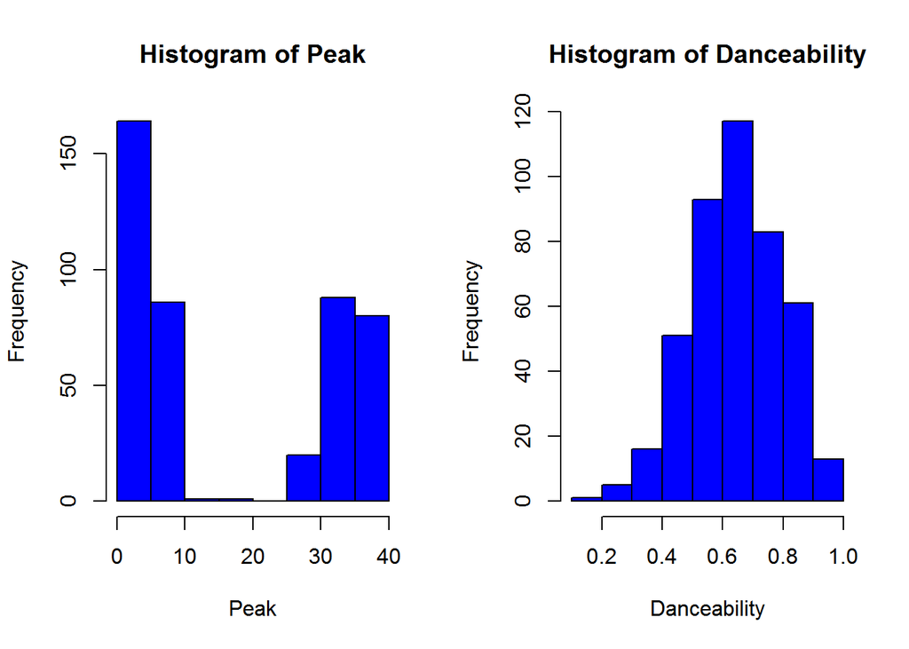

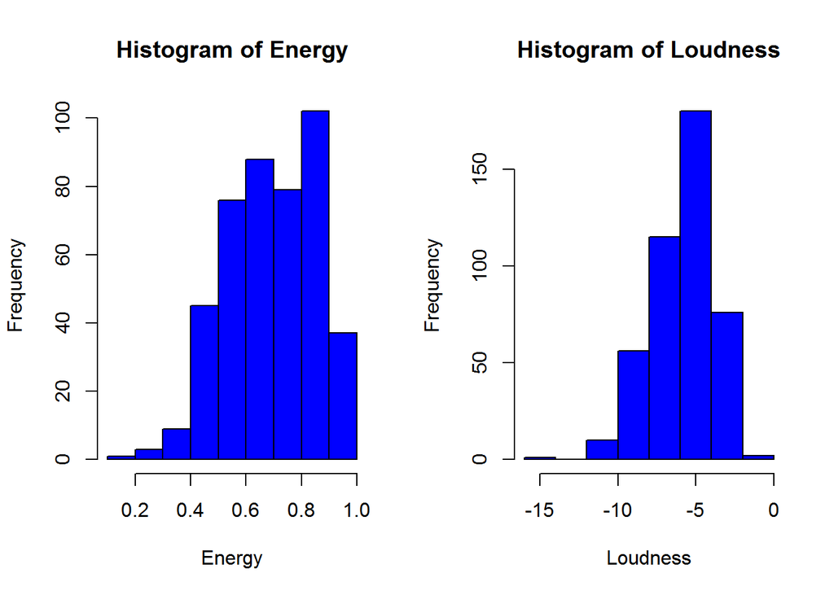

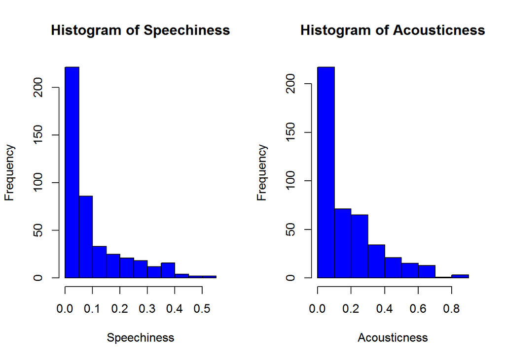

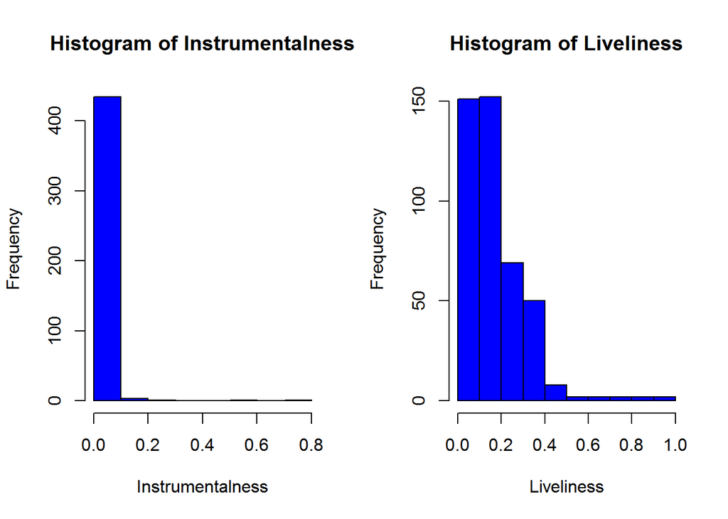

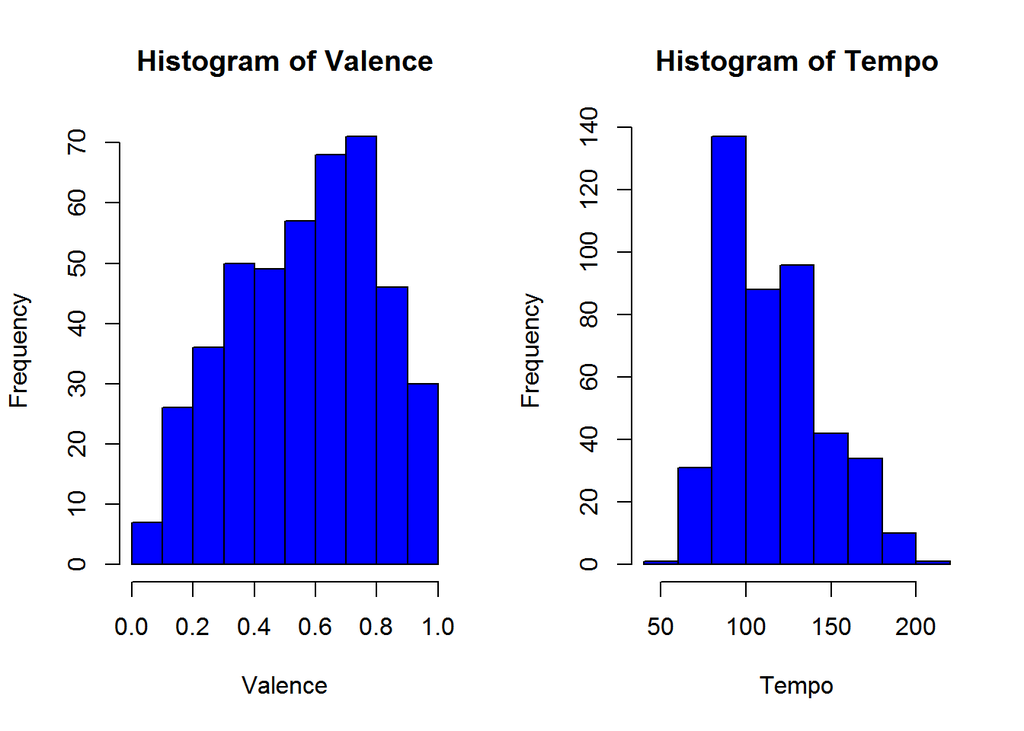

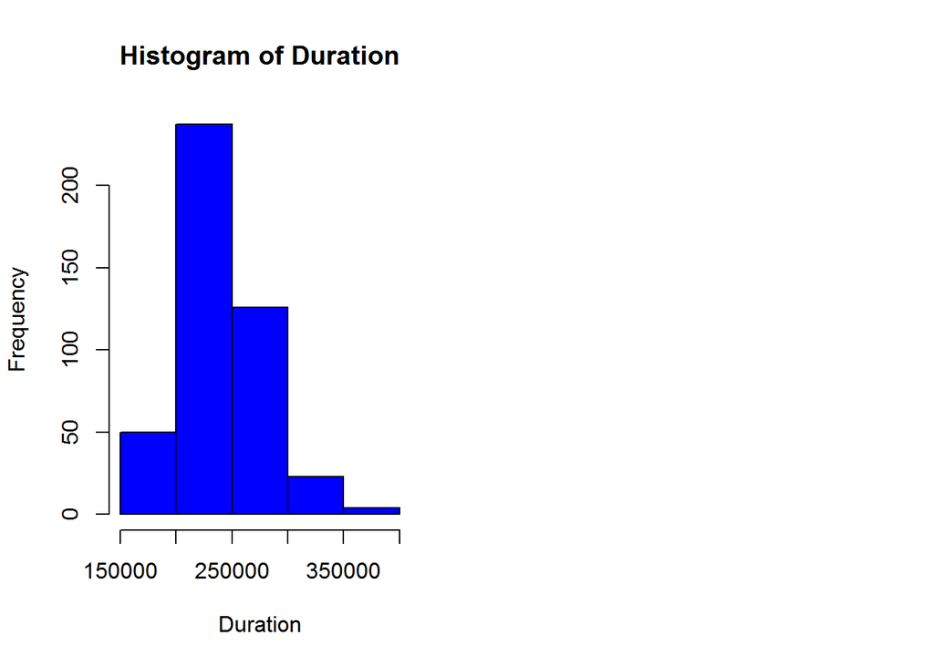

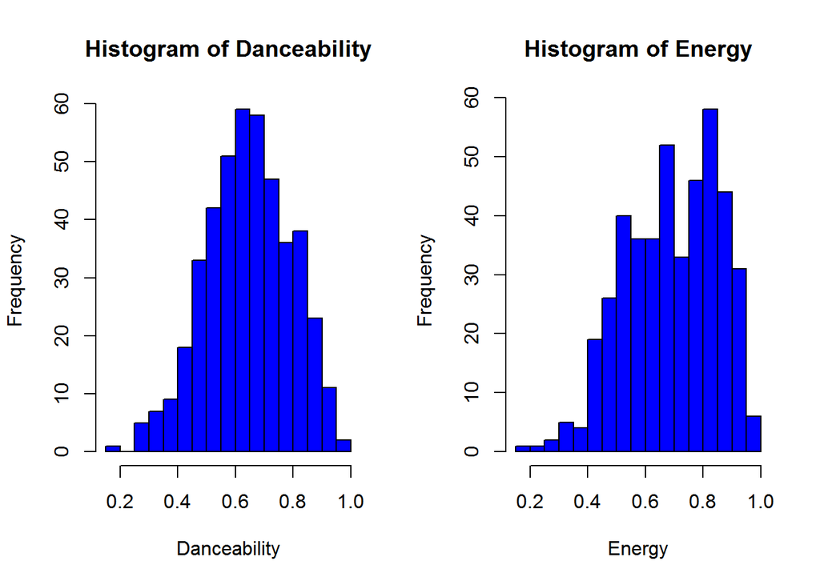

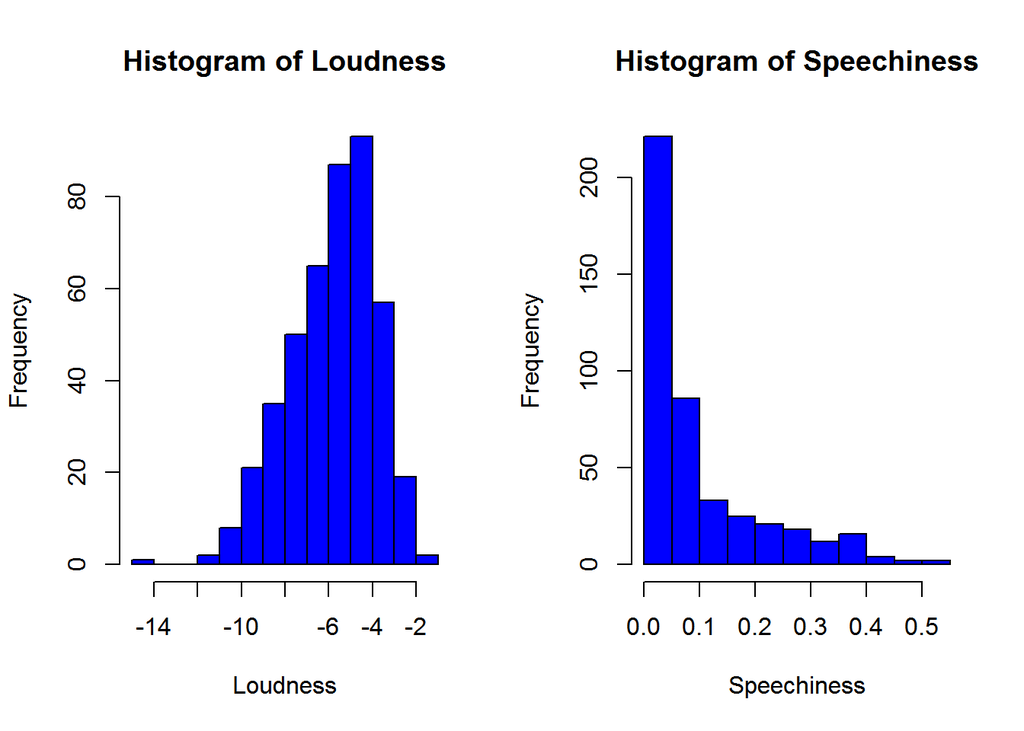

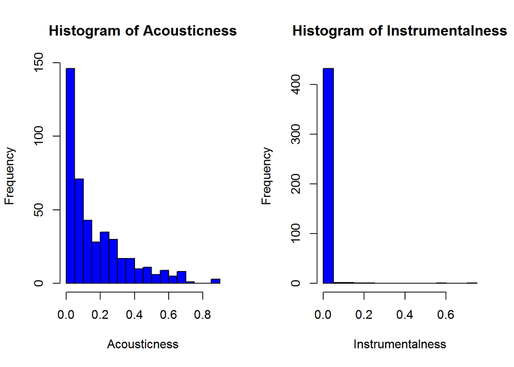

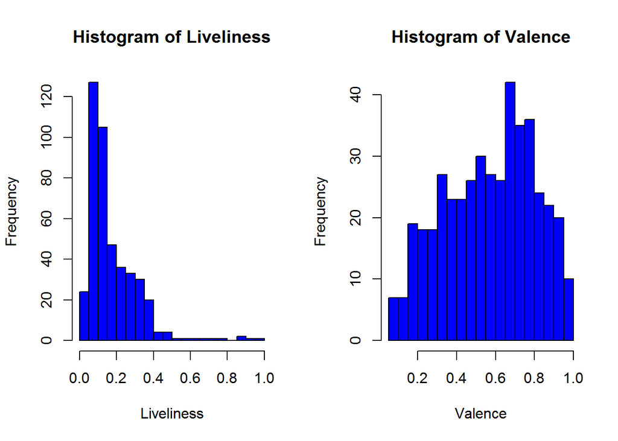

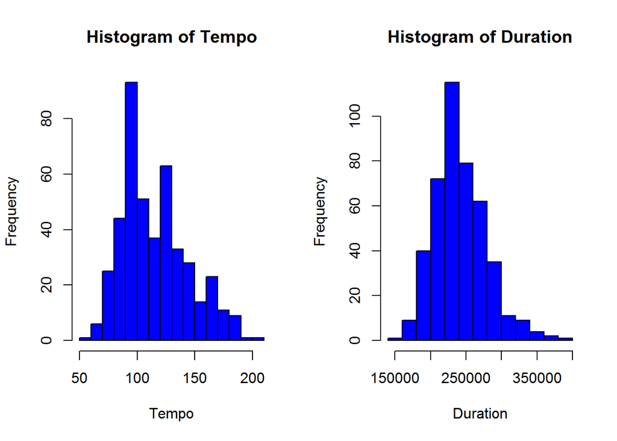

## Plotting Stacked histogram based on Succesfulness

The stacked histograms for the numerical values in songs data are plotted with regards to the succesfulness of the song.

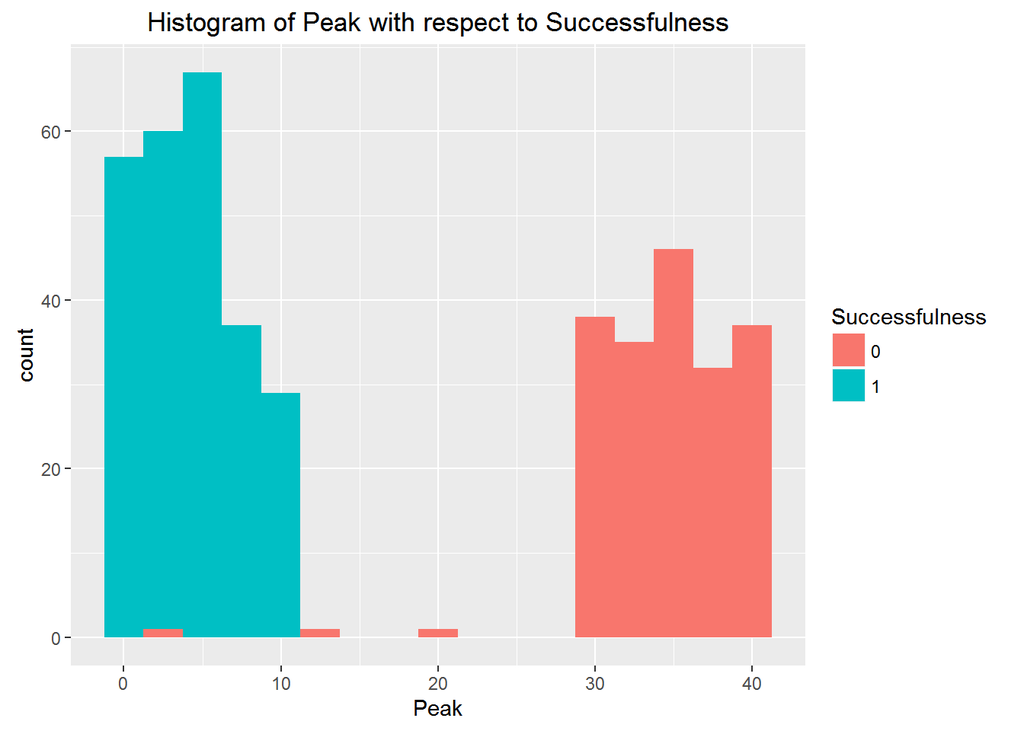

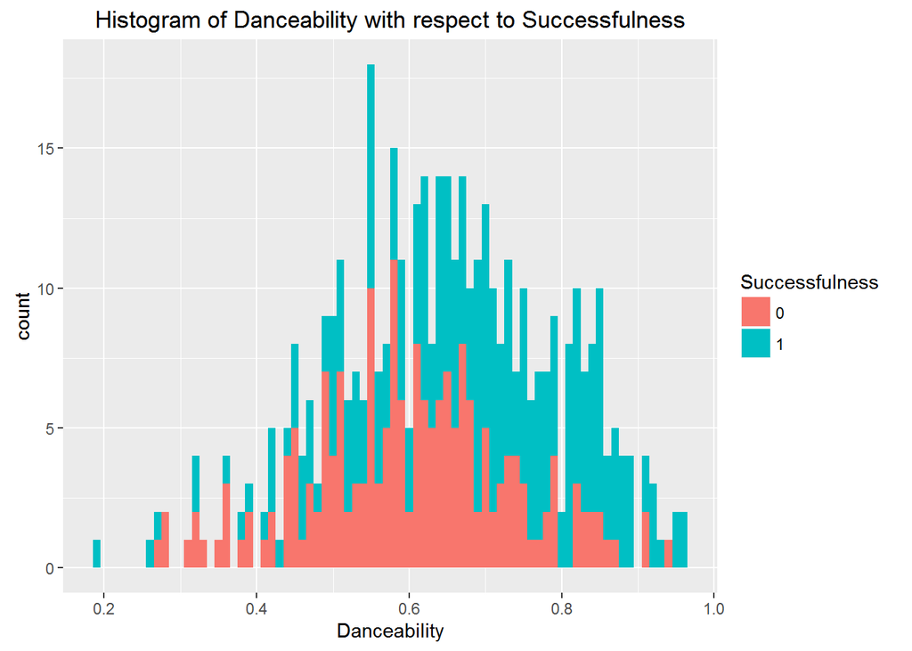

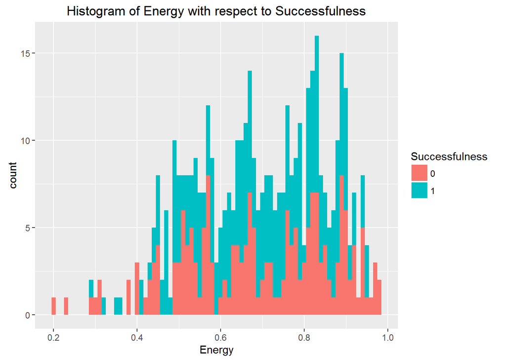

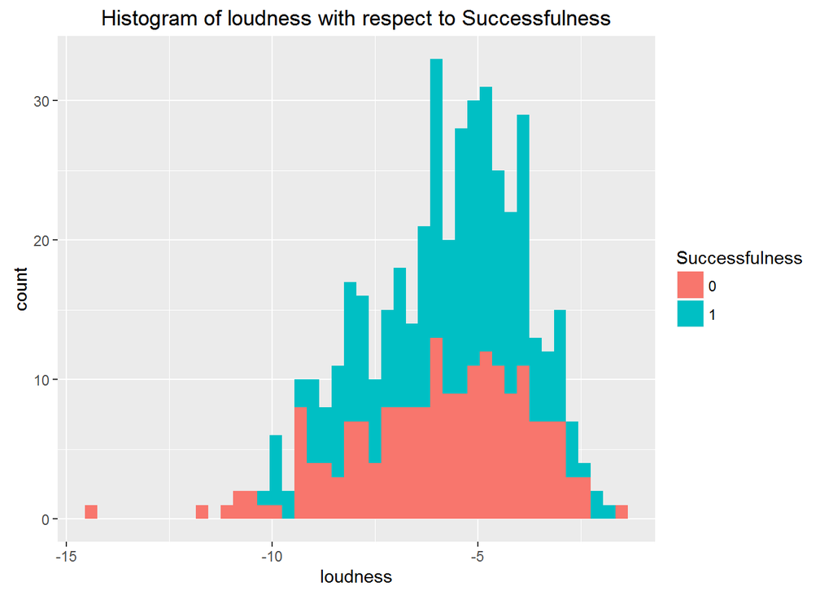

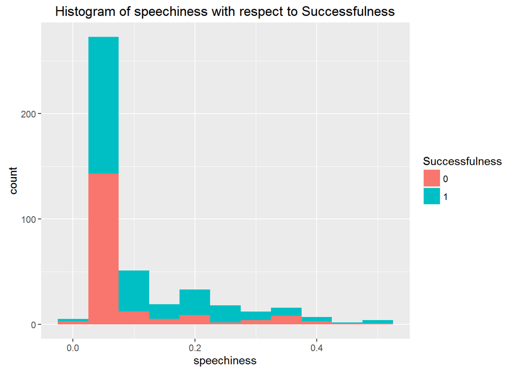

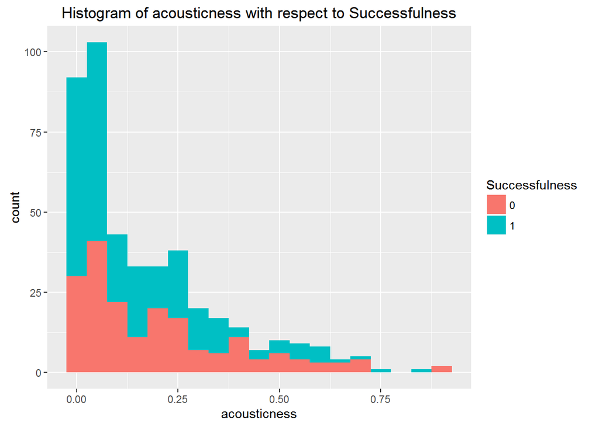

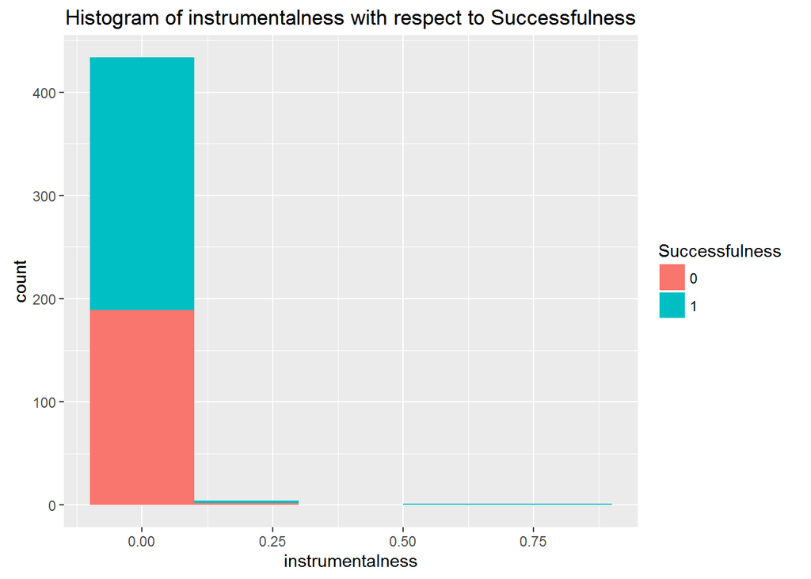

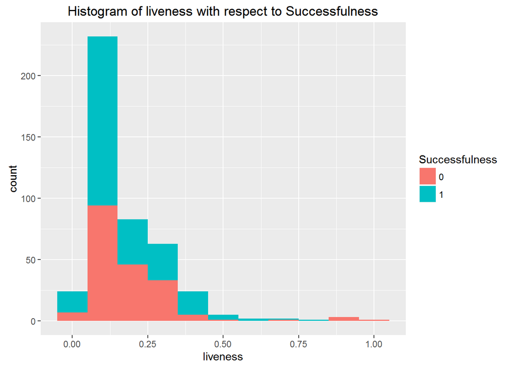

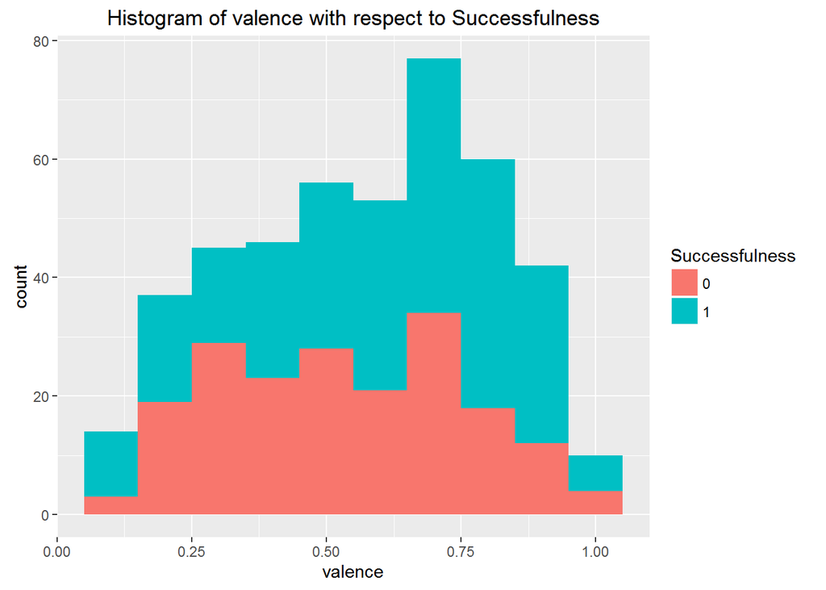

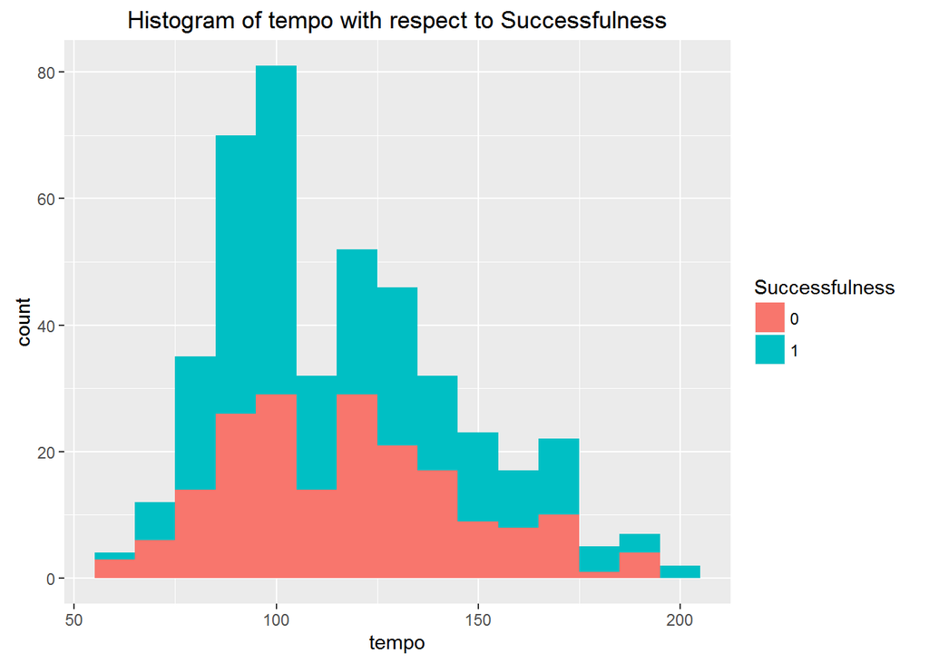

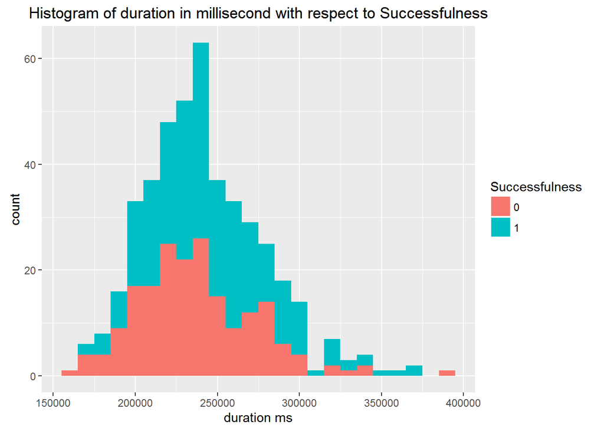

Inference:

## Plotting of stacked Boxplots based on Succesfulness

The stacked boxplots for the numerical values in songs data are plotted with regards to the succesfulness of the song.

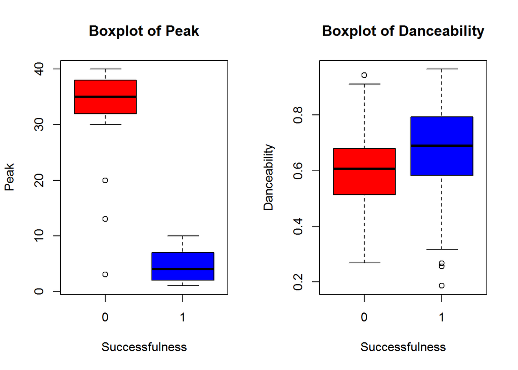

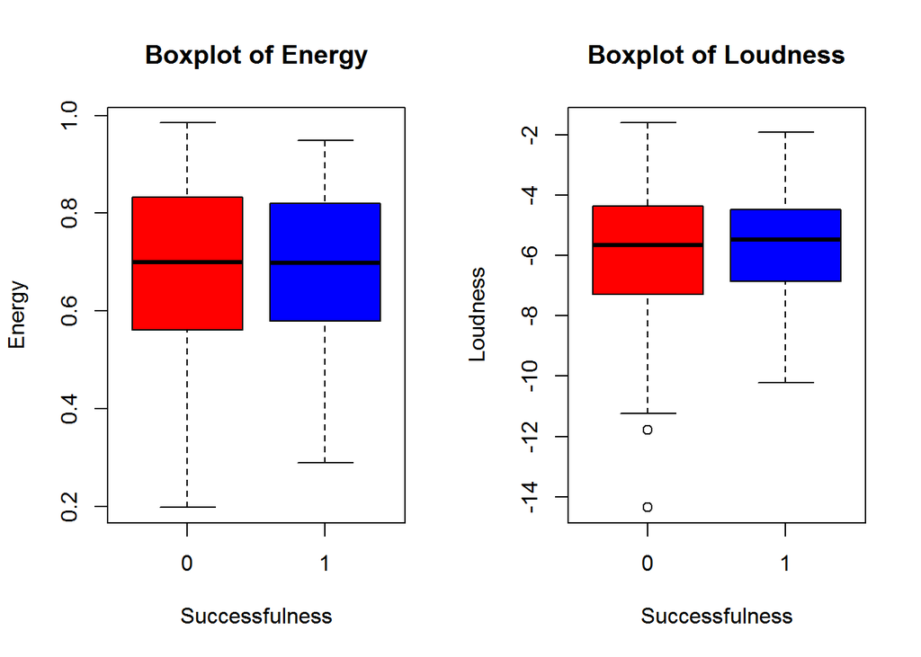

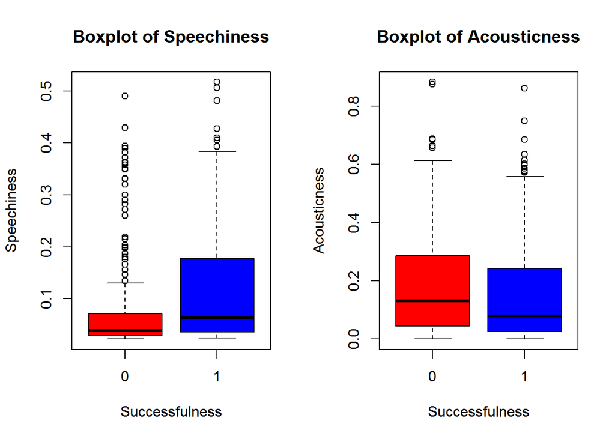

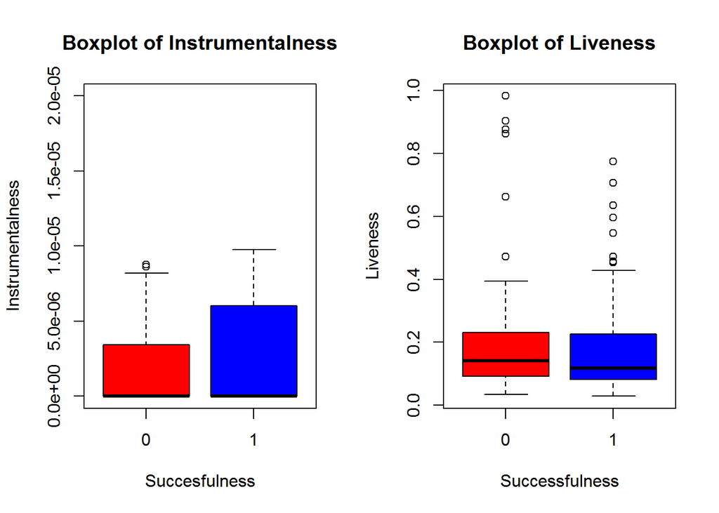

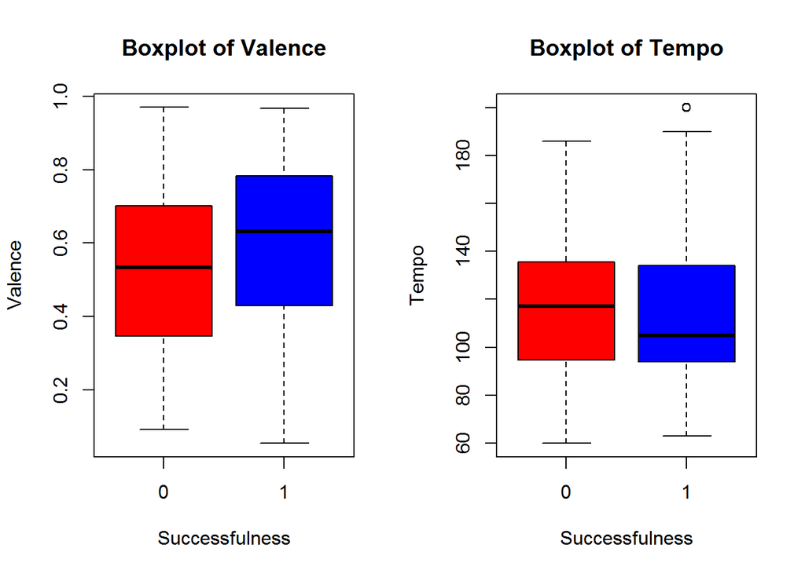

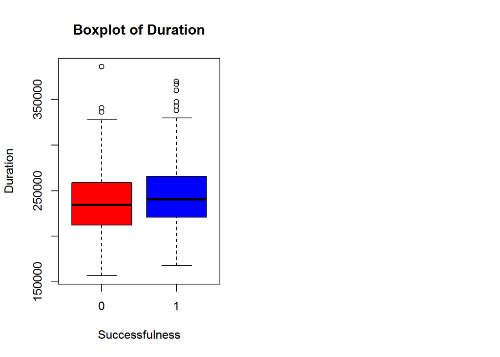

## Barplots based on categorical values

The analysis of categorical values for audio features of a song is best plotted by barplots. Here, the catgorical audio features such as mode, succesfulness, key and time signature are plotted.

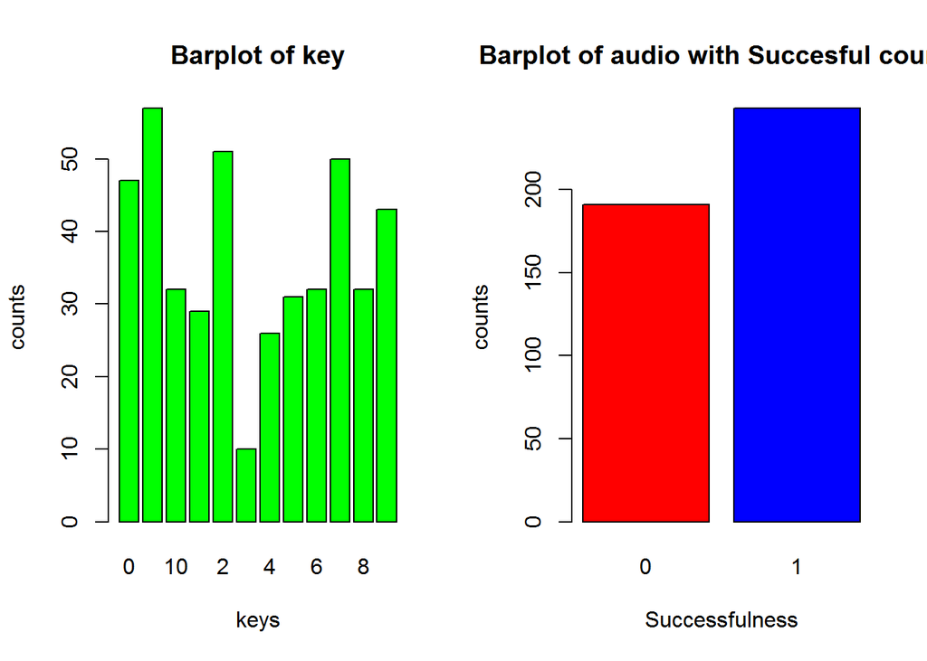

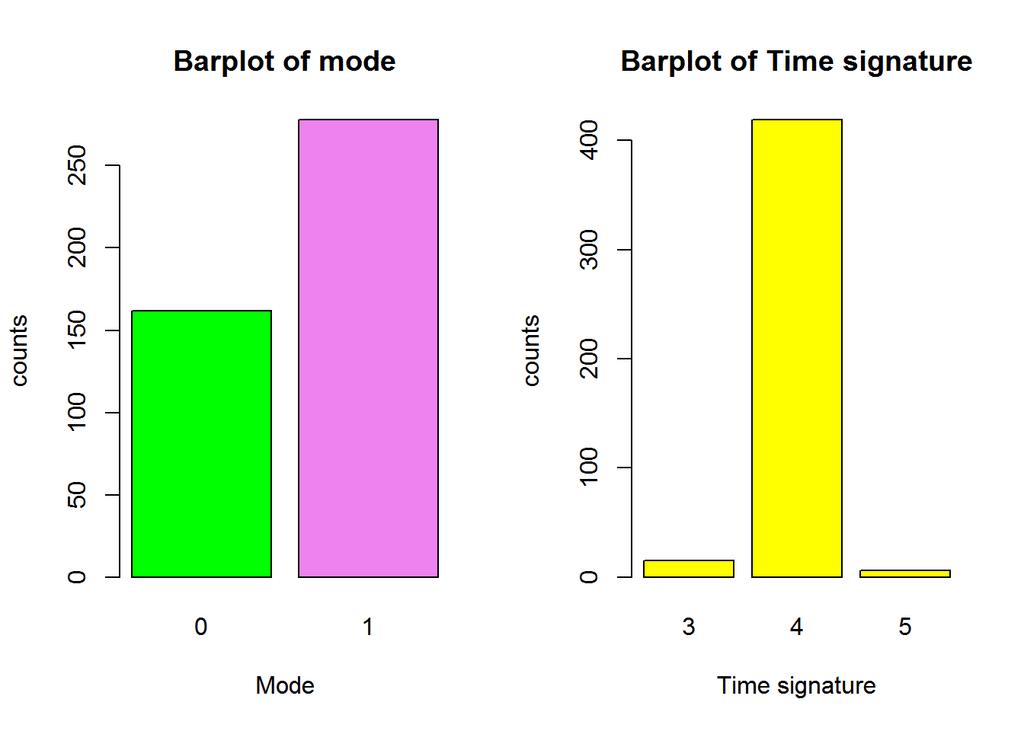